# Explore

Divya Bisht

12/2/2018

## Background & Objectives

Air pollution is known to have detrimental effects on human health. This study seeks to investigate air pollution, measured here as fine particulate matter (PM2.5), across New York State counties. In order to assess how PM2.5 exposure might be related to human health, we looked at asthma and cardiovascular (CVD) hospitalizations across New York counties. High PM2.5 causes damage to the respiratory system, which puts individuals at risk for health outcomes like asthma and heart disease.

Article: https://www.ncbi.nlm.nih.gov/pmc/articles/PMC5260007/

### Exploration

Initial PM2.5 data exploration was focused on New York City counties. However, limited data was available available, so NY state county data were selected to demonstrate the relationship between PM2.5 and hospitalizations of asthma and CVD.

```r
PM_county_NYS = read_csv("PM2.5_county_NYS.csv") %>%
  janitor::clean_names() %>%
  #filter(year == "2014") %>%
  select(county_name, year, output, measure) %>%
  separate(county_name, into = c("county", "delete", sep = " ")) %>%
  select(-delete) %>%
  mutate(county = recode(county, `New` = "New York"))
  #how to remove NA column?
```

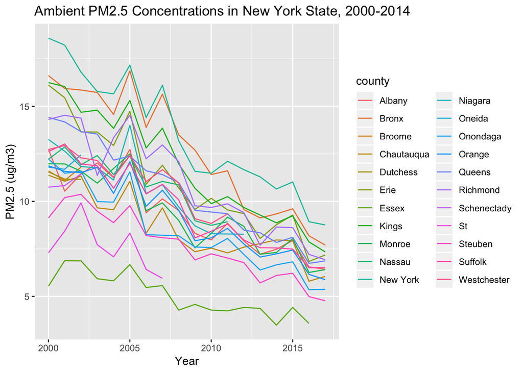

```r
PM_plot_conc_allyears = PM_county_NYS %>%
  filter(measure == "Micrograms/cubic meter (LC)") %>%
  group_by(county, year) %>%
  ggplot(aes(x = year, y = output, color = county)) + geom_line() + labs(title = "Ambient PM2.5 Concentrations in New York State, 2000-2014", x = "Year", y = "PM2.5 (ug/m3)")
PM_plot_conc_allyears
```

Next, we wanted to assess how PM2.5 exposure varied across counties in NY State.

#### PM2.5 EPA dataset

```r
nyc_pm25 = read_csv(file = "./data_AA/annual_aqi_by_county_2014.csv") %>%
  janitor::clean_names() %>%
  filter(state == "New York")
```

#### Days of PM2.5 by NY County

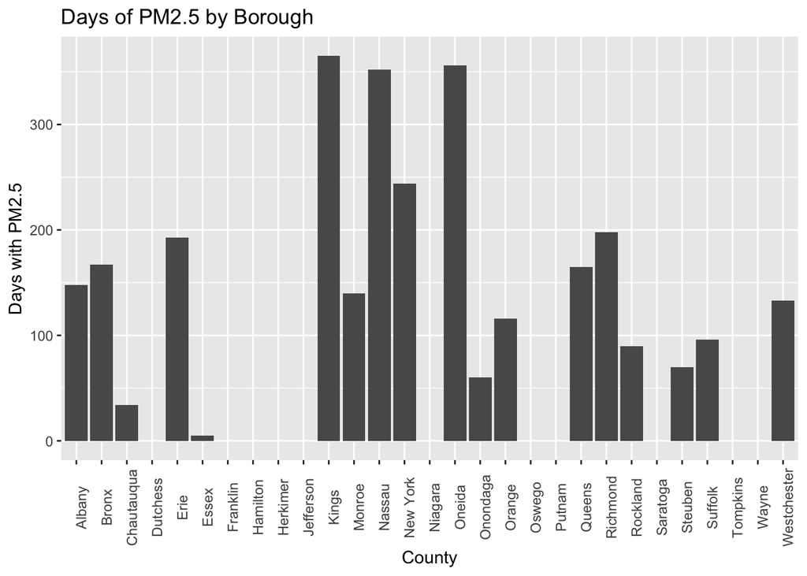

```r
pm_hist = nyc_pm25 %>%
  ggplot(aes(x = county, y = days_pm2_5)) +
  labs(
    title = "Days of PM2.5 by Borough",
    x = "County",
    y = "Days with PM2.5") +
  geom_histogram(stat = "identity") + theme(axis.text.x = element_text(angle = 90))
pm_hist
```

Literature shows that exposure to PM2.5 is associated with asthma and cardiovascular disease. Therefore, we wanted to assess hospitalization of asthma and CVD across counties.

#### Asthma ER Admissions Rate Dataset, 2014

```r
asthma_ER = read_csv("Asthma_ER_Rate_10000.csv") %>%
  janitor::clean_names() %>%
  #filter(county_name == "Bronx" | county_name == "Kings" | county_name == "Queens" | county_name == "Richmond" | county_name == "New York") %>%
  select(county_name, percentage_rate_ratio, data_years) %>%
  rename(asthma_ER_percent_rate = percentage_rate_ratio,
         asthma_ER_years = data_years) %>%
  filter(county_name != "Long Island" & county_name != "New York City" & county_name != "Mid-Hudson" & county_name != "Capital Region" & county_name != "Mohawk Valley" & county_name != "North Country" & county_name != "Tug Hill Seaway" & county_name != "Central NY" & county_name != "Southern Tier" & county_name != "Finger Lakes" & county_name != "Western NY" & county_name != "New York State (excluding NYC)" & county_name != "New York State") %>% #to remove non-county regions
  rename(county = county_name)
```

#### Plot Asthma ER Admissions per County, 2014

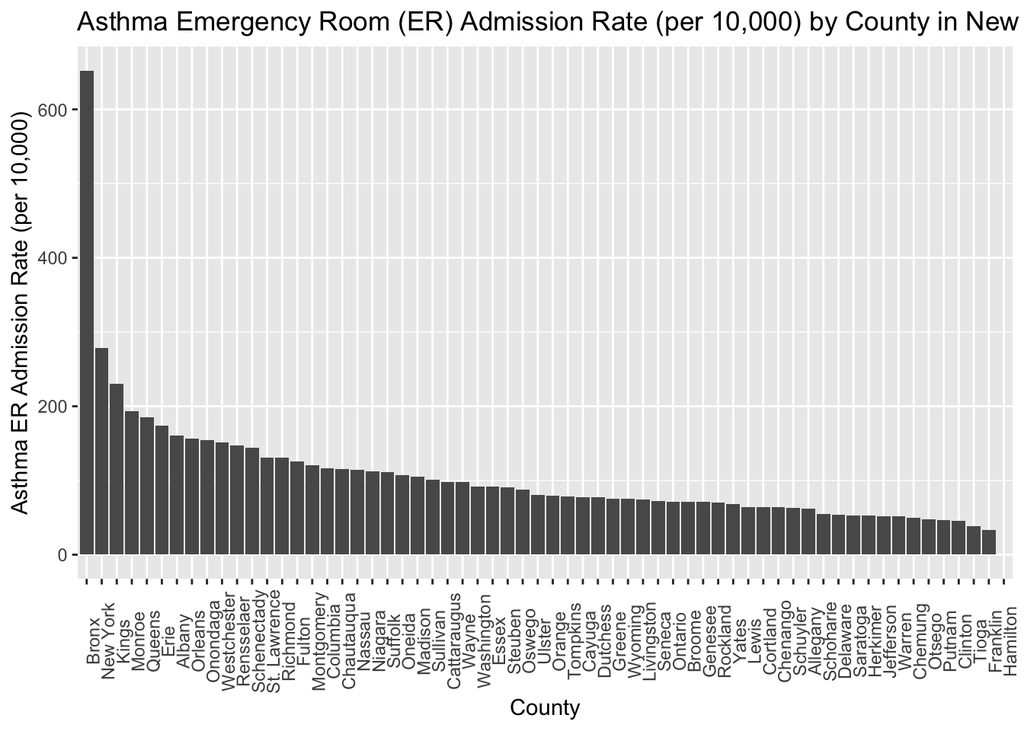

```r
asthma_plot_14 = asthma_ER %>%
    ggplot(aes(x = reorder(county, -asthma_ER_percent_rate), y = asthma_ER_percent_rate, group = 1)) + geom_histogram(stat = "identity") + theme(axis.text.x = element_text(angle = 90)) + labs(x = "County", y = "Asthma ER Admission Rate (per 10,000)", title = "Asthma Emergency Room (ER) Admission Rate (per 10,000) by County in New York State, 2014")
asthma_plot_14
```

#### Cardiovascular hospitalizations

```r
cvd_data = read_csv(file = "./data_AK/Community_Health__Age-adjusted_Cardiovascular_Disease_Hospitalization_Rate_per_10_000_by_County_Map__Latest_Data.csv") %>%
  janitor::clean_names() %>%
  filter(health_topic %in% "Cardiovascular Disease Indicators") %>%
  select(county_name, event_count, average_number_of_denominator,
         percent_rate)
```

#### Age-Adjusted CVD Hospitalization Rate in NY State, 2012 - 2014

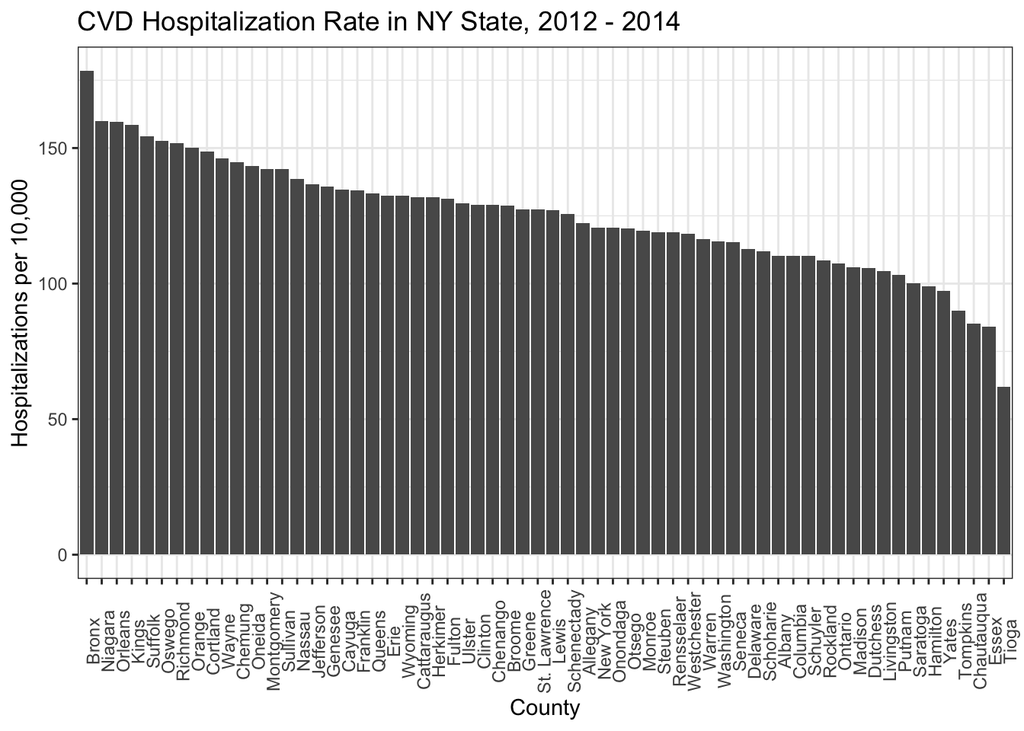

```r
cvd_data %>%
  ggplot(aes(x = reorder(county_name, -percent_rate), y = percent_rate)) +
  labs(
    title = "CVD Hospitalization Rate in NY State, 2012 - 2014",
    x = "County",
    y = "Hospitalizations per 10,000") +
  geom_histogram(stat = "identity") +
  theme_bw() +
  theme(axis.text.x = element_text(angle = 90), legend.position = "none")
```

## Data Sources

- NYSDOH Health Data
- US EPA AQS
- Environment & Health Data Portal

## Conclusions & Future Directions